# Introducing AnyFit R Package

Timeseries analysis of hydro-climatic variables is crucial for the study of relevant physical processes as well as the design and forcing of a plethora of physical and statistical models. However, physical processes exhibit a wide range of distinct features that complicate their study. For example:

- Seasonality
- Over-annual trends - long-term persistence
- Intermittency
- Highly skewed distributions
- Different forms of autocorrelation

Importantly, many of these physical characteristics act on different scales, ranging from very fine (e.g. hourly) to very large (e.g. annual or decadal). Additionally, advances in different technology sectors, with a prominent position of the remote sensing industry, have made publicly accessible, large databases of ground (e.g. NASA MODIS, KNMI) and remote observations, hindcast and reanalysis models. All of the above imply that tools developed for timeseries analysis, or more commonly known exploratory data analysis (EDA) should:

- Be data agnostic
- Be able to handle multiple temporal scales
- Be easily extensible
- Be able to handle large sets of data from multiple stations/locations efficiently
- Be able to work with NetCDF files

AnyFit aims to address the above demands in a robust manner. It is based on the eXtensible Time Series (xts) data format, which is a powerful package that provides an extensible time series class, enabling uniform handling of many R time series classes by extending zoo. Moreover, all visualization functions are implemented in ggplot2 package. AnyFit is developed with practitioners and researchers in mind. In this manner it streamlines the EDA with the stochastic modelling of hydrocliamtic variables using the anySim package, thus setting the foundations for a timeseries analysis and modeling ecosystem. Notable examples of anyFit functionality include:

- Read directly from delimited files to xts format
- Identify gaps in data
- Produce summary statistics at various temporal scales (e.g. monthly, annual) with ease
- Perform distribution fitting at various temporal scales (e.g. monthly, annual) with ease
- Provides support for some “exotic” distributions, such as the Dagum and BurXII
- Extent summary statistics and distribution fitting functionality directly to spatial data and produce NetCDF files with results
- Streamline the visualisation of spatial statistics

In detail the distributions supported by anyFit are the following: * Exponential * Rayleigh * Gamma * Normal * Log-Normal * Generalized Logistic * 3-parameter Weibull * Gumbel * 3-parameter Gamma (PearsonIII) * Generalized Extreme Value Distribution (GEV) * Generalized Pareto Distribution (GPD) * Generalized Gamma * Generalized Gamma with location * BurXII * Dagum * Exponentiated Weibull

In the present document we are going to present the package capabilities based on point precipitation measurements and gridded re-analysis data. Additionally, we will provide two practical examples of stochastic modeling, one univariate and one cyclostationary univariate, using the anySim package.

```r
library(anyFit)
```

The analysis begins with loading the historical data. This is done by delim2xts function. It receives data in a delimited file which a column contains the dates and each other column presents a timeseries entry, e.g. a different station or a process. Data have to be in a strict time step and this has to be provided as an arguments. The date format of the date column has to be known, as well as the file delimiter. Additionally, it can receive arguments for skipping file lines, excluding leap years and others. Missing data are formally treated by introducing NANs.

```r
file_path <- system.file("extdata", "KNMI_Daily.csv", package = "anyFit")
time_zone <- "UTC"

data <- delim2xts(file_path = file_path,
                  time_zone = "UTC", delim = " ", strict_step = TRUE)
```

```
#> Time difference of 1 days
```

Having loaded the data we should interrogate them for missing values. This can be done for different time scales of interest. In this example we choose to examine the first 4 stations in monthly and annual scales.

[figure not shown]

```r
missing <- check_missing(data[,seq(1,4)], c("months","years"))
missing$list_years$figure
```

It appears that we have a complete data set. We can know plot some basic features for station 4.

```r
bstats <- basic_stats(data[,4], pstart = '2002',pend = '2005', show_table = FALSE,
                      show_label = FALSE, ignore_zeros = TRUE)
```

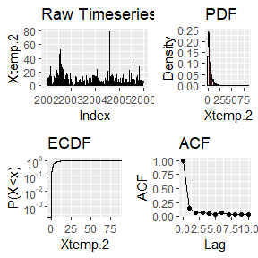

```r
bstats$plot
```

Additonaly, basic_stats will return a table with the basic statistics and the quantiles.

```r
bstats$stats_table
```

```
#>                         Value
#> NumofData         38690.00000
#> NumofMisData          0.00000
#> PercOfMissingData     0.00000
#> Min                   0.02000
#> Max                  85.50000
#> Mean                  4.15000
#> Var                  27.36000
#> StDev                 5.23000
#> Variation             1.26000
#> Mom3                479.67000
#> Skewness              3.35000
#> Kurtosis             25.00000
#> Lmean                 4.15000
#> LScale                2.37000
#> L3                    0.99000
#> L4                    0.51000
#> LVariation            0.57000
#> LSkewness             0.42000
#> LKurtosis             0.21000
#> Pdr                   0.50000
#> Q5                    0.15000
#> Q25                   0.80000
#> Q50                   2.38000
#> Q75                   5.55000
#> Q95                  13.90000
#> IQR                   4.75000
#> MeanDAfterZero        3.52892
#> VarDAfterZero        23.00755
#> MeanDBeforeZero       3.22101
#> VarDBeforeZero       20.99273
#> MeanDAfterD           4.42151
#> VarDAfterD           29.07098
```

```r
bstats$quantiles_table
```

[output not shown]

The above statistics concerns the original scale of the data, i.e. daily. However, hydroclimatic processes act on different temporal scales. Therefore, it is useful to aggregate the data to several different temporal scales and examine their statistical properties. We will begin by aggregating and plotting in monthly, quarterly and annual scales.

[figure not shown]

```r
agg_ts <- aggregate_xts(ts = data[,4], periods = c("months","quarters","years"), FUN = 'sum')
smonthly_ts <- agg_ts$list_months$aggregated
agg_ts$Combined_Plot
```

This plot demonstrated the precipitation variability at different time scales. It should be noted that an arbitrary season can be defined instead of a predefined scale, for example a wet and a dry season in a region near the equator. It is usual practice to examine timeseries on a monthly basis since it an intuitive scale and in this way it is possible to capture cyclostationary behavior. Using monthly stats we can extract monthly statistics in the original and the aggregated temporal scales for each month.

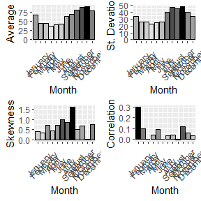

```r
defaultW <- getOption("warn")
options(warn = -1)
monthly_sts <- monthly_stats(data[,4],aggregated = TRUE, FUN = "sum")
monthly_sts$faggre
```

Additionaly, we can plot tables with statistics in similar fashion as basic_stats.

```r
monthly_sts$agg_stats
```

```
#>                       January   February       March      April         May
#> NumofData           106.00000  106.00000   106.00000  106.00000   106.00000
#> NumofMisData          0.00000    0.00000     0.00000    0.00000     0.00000
#> PercOfMissingData     0.00000    0.00000     0.00000    0.00000     0.00000
#> Min                   5.40000    1.41000     2.30000    0.40000     0.75000
#> Max                 164.99000  126.50000   110.03000   92.70000   118.40000
#> Mean                 67.27000   45.47000    44.48000   37.91000    40.23000
#> Var                1127.77000  651.14000   648.52000  496.74000   629.05000
#> StDev                33.58000   25.52000    25.47000   22.29000    25.08000
#> Variation             0.50000    0.56000     0.57000    0.59000     0.62000
#> Mom3              16267.85000 5909.44000 11675.58000 5009.10000 11189.31000
#> Skewness              0.43000    0.36000     0.71000    0.45000     0.71000
#> Kurtosis              3.00000    3.00000     3.00000    2.00000     3.00000
#> Lmean                67.27000   45.47000    44.48000   37.91000    40.23000
#> LScale               18.93000   14.55000    14.25000   12.72000    14.05000
#> L3                    1.41000    0.86000     2.23000    1.40000     2.14000
#> L4                    2.58000    1.10000     1.66000    0.64000     1.56000
#> LVariation            0.28000    0.32000     0.32000    0.34000     0.35000
#> LSkewness             0.07000    0.06000     0.16000    0.11000     0.15000
#> LKurtosis             0.14000    0.08000     0.12000    0.05000     0.11000
#> Pdr                   0.00000    0.00000     0.00000    0.00000     0.00000
#> Q5                   14.15000    6.83000    10.52000    8.50000     5.47000
#> Q25                  45.48000   25.82000    25.23000   19.35000    22.98000
#> Q50                  65.06000   42.23000    40.45000   35.70000    35.30000
#> Q75                  88.12000   65.88000    58.60000   54.07000    53.53000
#> Q95                 123.80000   87.50000    87.17000   75.17000    88.10000
#> IQR                  42.64000   40.06000    33.37000   34.72000    30.55000
#> MeanDAfterZero            NaN        NaN         NaN        NaN         NaN
#> VarDAfterZero              NA         NA          NA         NA          NA
#> MeanDBeforeZero           NaN        NaN         NaN        NaN         NaN
#> VarDBeforeZero             NA         NA          NA         NA          NA
#> MeanDAfterD          67.05548   45.22534    44.73421   37.93738    40.22183
#> VarDAfterD         1133.66218  651.15907   647.81240  501.42920   635.09974
#> ProbDD                1.00000    1.00000     1.00000    1.00000     1.00000
#> ProbNDND              0.00000    0.00000     0.00000    0.00000     0.00000
#>                          June        July       August   September     October
#> NumofData           106.00000   106.00000    106.00000   106.00000   106.00000
#> NumofMisData          0.00000     0.00000      0.00000     0.00000     0.00000
#> PercOfMissingData     0.00000     0.00000      0.00000     0.00000     0.00000
#> Min                   0.01000     0.63000      9.50000     1.30000     0.37000
```

[output cut: 50 more lines]

```
#> Pdr                  0.0000     0.00000
#> Q5                  34.0000    31.88000
#> Q25                 58.5400    54.65000
#> Q50                 89.6500    75.74000
#> Q75                118.0100    95.08000
#> Q95                158.2000   145.73000
#> IQR                 59.4700    40.43000
#> MeanDAfterZero          NaN         NaN
#> VarDAfterZero            NA          NA
#> MeanDBeforeZero         NaN         NaN
#> VarDBeforeZero           NA          NA
#> MeanDAfterD         89.5911    78.50068
#> VarDAfterD        1543.4988  1146.88956
#> ProbDD               1.0000     1.00000
#> ProbNDND             0.0000     0.00000
```

Data visualization is widely recognized for playing an essential role in both data comprehension and result communication. For this reason we are providing wrappers for three commonly used type of plots, boxplots, violin plots and ridge plots. The first two group variables by month. This way they provide a good understanding of inter-annual variability.

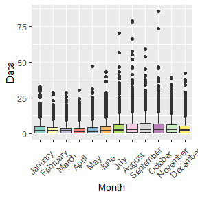

```r
boxes <- monthly_boxplots(data[,4], palette = 'Set3', ignore_zeros = TRUE)
boxes
```

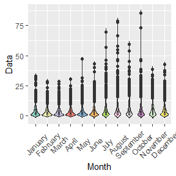

```r
violins <- monthly_violins(data[,4], palette = 'Set3', ignore_zeros = TRUE)
violins
```

Ridge plots are implemented for both different timeseries and monthly scale within a single timeseries.

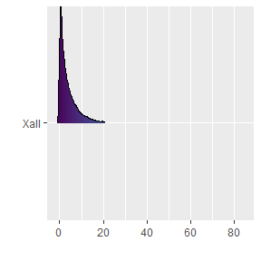

```r
ridges <- ridge_plots(data[,c(1)], ignore_zeros = TRUE)
ridges$plot_all
```

```r
ridges$plot_monthly$Y.Xtemp.2
```

[output not shown]

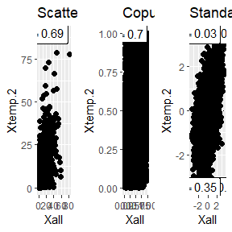

```r
correls <- correl_plots(data[,1],data[,4], check_common = TRUE, ignore_zeros = TRUE)
correls$combined
```

Another important component of timeseries is the autocorrelation function. Strong autocorrelations with heavy tails will result in the clustering of values, e.g. series of high or low values. On the contrary weak autocorrelations imply a bahviour simillar to random noise. Currently, AniFit contains three theoretical autocorrelation functions, namely, Cauchy, Hurst-Kolmogorov (HK) and the short range or exponential. These functions can be fitted to the available data.

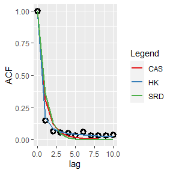

```r
acfs <- fit_ACF(data[,4], lag = 10, ignore_zeros = TRUE )
acfs$ACF_plot
```

Additionally, in a similar manner to monthly_stats, fit_ACF_monthly function fits the theoretical ACFs on a monthly level.

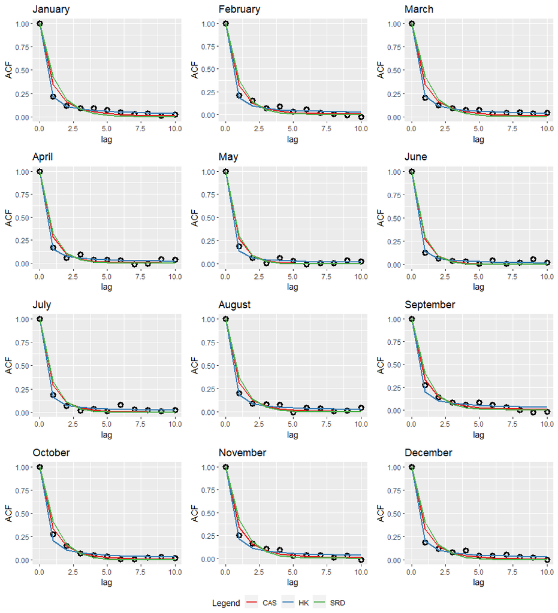

```r
monthly_acfs <- fit_ACF_monthly(data[,4], lag = 10)
monthly_acfs$ACF_monthly_plot
```

Last but not least, AnyFit package incorporates L-Moment estimators for the following functions:

- Exponential
- Rayleigh
- Gamma
- Normal
- Log-Normal
- Generalized Logistic
- 3-parameter Weibull
- Gumbel
- 3-parameter Gamma (PearsonIII)
- Generalized Extreme Value Distribution (GEV)
- Generalized Pareto Distribution (GPD)
- Generalized Gamma
- Generalized Gamma with location
- BurXII
- Dagum
- Exponentiated Weibull

The definition of the relevant function for the above distributions follows the typical definition of R language, e.g. qgamma for the quantile function of Gamma, pexp for the CDF of Exponential and rdagum for the random number generator of Dagum. The fitting function for each of the above are defined with the prefix “fitlm_”. For example we try to fit the Exponentiated Weibull to station 4 data and get the distribution parameters and some goodness of fit measures.

```r
params <- fitlm_expweibull(data[,4], ignore_zeros = TRUE)
params$Param
```

```
#> $scale
#> [1] 3.399303
#>
#> $shape1
#> [1] 0.7862285
#>
#> $shape2
#> [1] 1.089002
```

```r
params$GoF
```

```
#> $MLE
#> [1] NaN
#>
#> $CM
#> [1] 1832.587
#>
#> $KS
#> [1] 0.2510545
#>
#> $MSEquant
#> [1] 125.0537
#>
#> $DiffOfMax
#> [1] -100
#>
#> $MeanDiffOf10Max
#> [1] 0.6581123
```

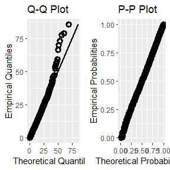

```r
fit_check <- fit_diagnostics(data[,4], dist = 'expweibull',
                             params = params$Param, ignore_zeros = TRUE)
fit_check$Diagnostic_Plots
```

[figure not shown]

```r
candidates <- list('exp','expweibull', 'gamma3')
fits <- fitlm_multi(data['2010',4],candidates = candidates, ignore_zeros = TRUE)
fits$diagnostics
```

A table with the GoF measures is also provided.

```r
fits$GoF_summary
```

```
#>                          exp    expweibull        gamma3
#> MLE             458.64903823  445.48792141           Inf
#> CM                0.13394241    0.03170196    0.04868285
#> KS                0.09135302    0.04377095    0.06143092
#> MSEquant        186.45343213  191.46853585  190.99275606
#> DiffOfMax       -99.24485871 -100.26709282 -101.70882932
#> MeanDiffOf10Max  20.97227237   21.29753715   21.57903144
```

We know have all of the information needed to construct a synthetic timeseries based in the measured data. We are going to employ AutoRegressive To Anything (ARTA) model from the anySim package to simulate 100 years of daily precipitation.

```r
library(anySim)
set.seed(12)
# Define the target autocorrelation structure.
ACS=csCAS(param=c(acfs$ACF_params$CAS$beta,acfs$ACF_params$CAS$kappa),lag=1000) # CAS with b=3 and k=0.6
# Define the target distribution function (ICDF).
FX='qexpweibull' # Gamma distribution
# Define the parameters of the target distribution.
pFX <- params$Param
# Estimate the parameters of the auxiliary Gaussian AR(p) model.
ARTApar=EstARTAp(ACF=ACS,dist=FX,params=pFX,NatafIntMethod='GH')
# Generate a synthetic series of 10000 length.
SynthARTAcont=SimARTAp(ARTApar=ARTApar,steps=36494)
```

We can easily “package” the synthetic timeseries in a xts format and use the existing tools to visualise and examine the model performance.

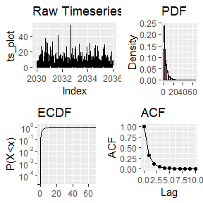

```r
simVector <- unlist(SynthARTAcont$X)
date_format <- "%d/%m/%Y"
starttime=as.POSIXct('01/01/2021',format=date_format, tz = time_zone)
endtime=as.POSIXct('01/12/2120',format=date_format, tz = time_zone)
dates <- seq(from = starttime, to = endtime, by = '1 day')
simARTA_Xts <- xts::xts(x = simVector, order.by = dates)

uni_check <- basic_stats(simARTA_Xts, pstart = '2030', pend = '2035',show_table = FALSE,
                         show_label = FALSE, ignore_zeros = TRUE )
uni_check$plot
```

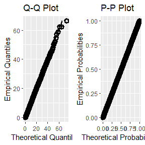

```r
univ_fcheck <- fit_diagnostics(simARTA_Xts, dist = 'expweibull', params = params$Param, ignore_zeros = TRUE)
univ_fcheck$Diagnostic_Plots
```

Additionally, there are cases when a bulk investigation of multiple timeseries is required. In such cases examining the diagnostics from 10s or 100s of stations may not be feasible. On way to approach this is to plot the L-CV space of several distributions and compare it with the observed ones. This will narrow down the candidate distributions to fit. Currently, this test is only implemented for the Dagum, Generalized Gamma, Exponentiated Weibull and BurXII distributions. Additionally, the percentage of points inside the domain of each distribution is plotted.

```r
ts_lmoms <- lmom_stats(data, ignore_zeros = TRUE)

lcheck <- LRatio_check(ts_lmoms)
```

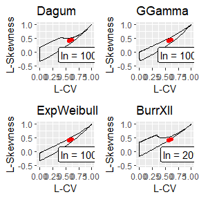

```r
lcheck$multi_plots
```

```r
start.time <- Sys.time()
fits_all <- fitlm_nxts(data, candidates, nrow = 5, ncol = 4, ignore_zeros = TRUE)
end.time <- Sys.time()
elapsed.time <- round((end.time - start.time), 3)
print(elapsed.time)
```

```
#> Time difference of 1.351 mins
```

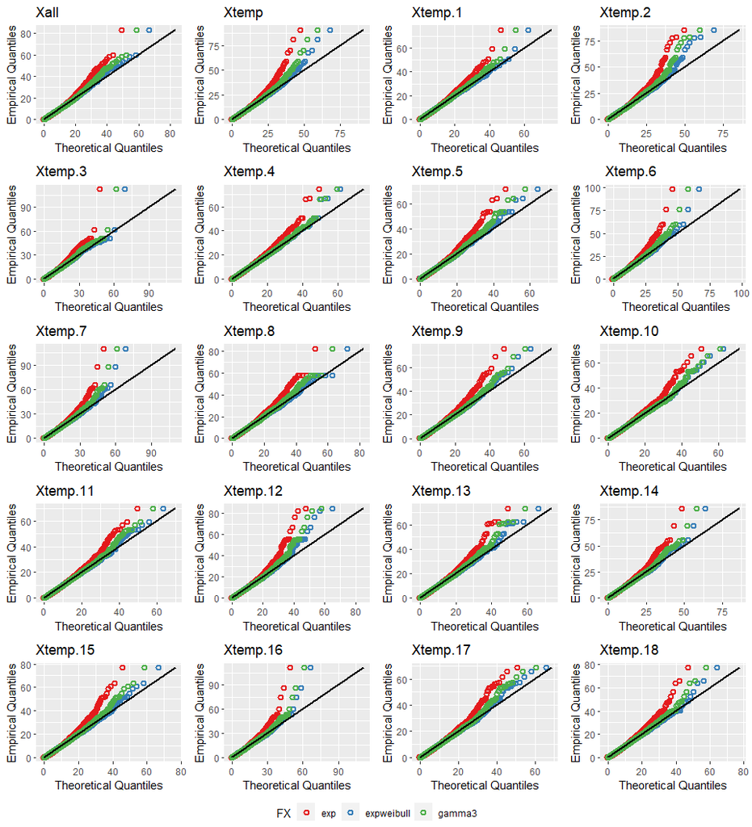

```r
fits_all$QQ_panels[[1]]
```

Final step on our presentation and analysis is the reproduction of a cyclostationary process. Using function fitlm_monthly we can fit distributions on the monthly precipitations, which where aggregated at the initial steps using function aggregate_xts. We can plot the diagnostics (QQ and PP plots) as well as a summary table with the goodness of fit measures.

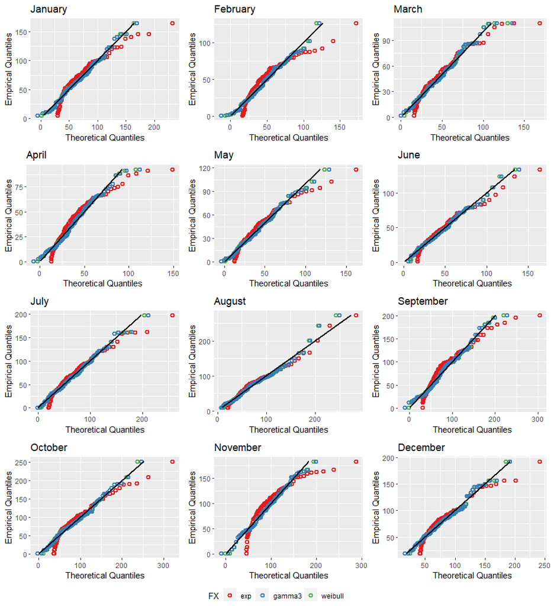

```r
candidates <- list('exp','weibull', 'gamma3')
monthly_fits <- fitlm_monthly(smonthly_ts,candidates = candidates, ignore_zeros = TRUE)
monthly_fits$monthly_QQplot
```

```r
monthly_fits$GoF_monthly$exp
```

```
#>                       January      February         March        April
#> MLE                       Inf           Inf           Inf          Inf
#> CM                  0.3629850     0.2858224     0.1478729    0.2339356
#> KS                  0.1432773     0.1323411     0.1148384    0.1095525
#> MSEquant        22470.7060590 10821.7751504 10444.4277234 7713.2583015
#> DiffOfMax        -118.0365740  -113.1610911  -114.7730277 -113.7024222
#> MeanDiffOf10Max   165.2654219   110.0994245   113.8621840   93.6741828
#>                          May          June          July        August
#> MLE                      Inf           Inf           Inf           Inf
#> CM                 0.1675418  8.646259e-02  1.083571e-01  1.188590e-01
#> KS                 0.1215447  9.154459e-02  9.520604e-02  9.052519e-02
#> MSEquant        8943.8957915  1.014971e+04  2.297503e+04  2.770751e+04
#> DiffOfMax       -110.4643443 -1.121359e+02 -1.104543e+02 -1.077788e+02
#> MeanDiffOf10Max  105.3168222  1.141666e+02  1.720213e+02  1.973977e+02
#>                     September       October      November      December
#> MLE                       Inf           Inf           Inf           Inf
#> CM                  0.3206212     0.2909843     0.3841670     0.2278836
#> KS                  0.1523817     0.1374591     0.1539802     0.1277755
#> MSEquant        34520.7146084 40514.3638498 38670.0951727 29027.1990813
#> DiffOfMax        -115.2405269  -114.2488607  -124.6006684  -121.6173505
#> MeanDiffOf10Max   205.5249252   226.5798324   208.7511138   194.1335596
```

Using the above and the month to month correlations from monthly_stats earlier we can now simulate a cyclostationary monthly precipitation process.

```r
set.seed(21)
# Define the number of seasons.
NumOfSeasons=12 # number of months
# Define the (12) lag-1 season-to-season correlation coefficients
rtarget<-monthly_sts$lag1$Value + 0.03
# Define that distributions are of zero-inflated type.
FXs<-rep('qzi',NumOfSeasons)
# Define the parameters of the distribution function for each season.
PFXs<-vector("list",NumOfSeasons)

for (i in 1:NumOfSeasons){
  PFXs[[i]] <- c(p0= monthly_sts$agg_stats['Pdr',i],
                    Distr = match.fun('qgamma3'),
                    setNames(monthly_fits$params_monthly$gamma3[[i]], rownames(monthly_fits$params_monthly$gamma3[i])))
}

# Estimate the parameters of SPARTA model.
SPARTApar<-EstSPARTA(s2srtarget=rtarget, dist=FXs, params=PFXs,
                     NatafIntMethod='GH', NoEval=9, polydeg=8, nodes=11)
# Generate a cyclostationary synthetic series of 10000 length.
simSPARTA<-SimSPARTA(SPARTApar=SPARTApar, steps=1000)
```

As before, monthly_fdiagnostics can be used to interogate the synthetic data.

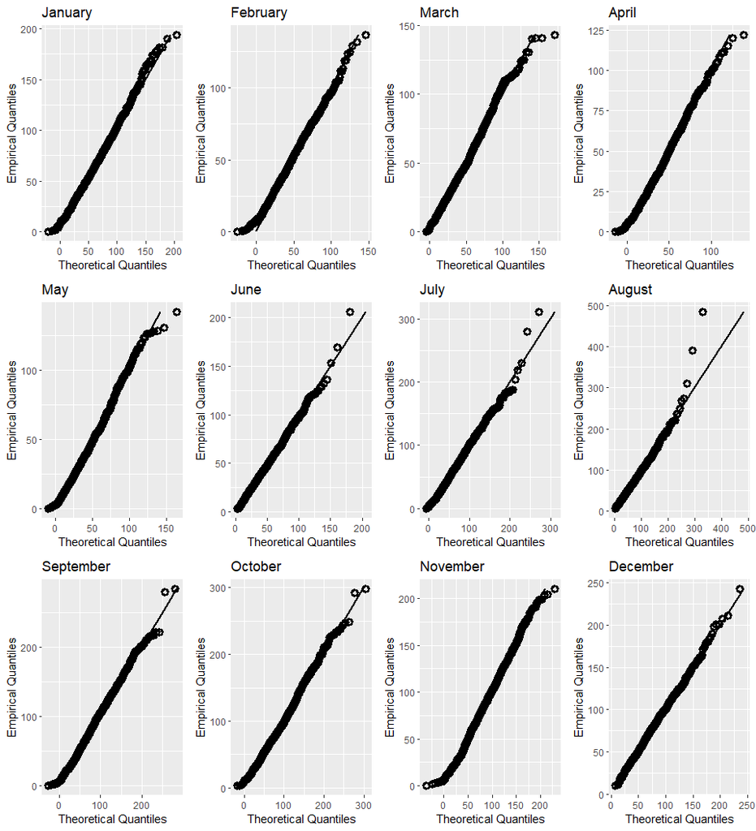

```r
simVector <- list()
for (i in 1:1000){
  simVector[[i]] <- simSPARTA$X[i,]
}

simVector <- unlist(simVector)
starttime=as.POSIXct('01/01/2021',format=date_format, tz = time_zone)
endtime=as.POSIXct('01/12/3020',format=date_format, tz = time_zone)
dates <- seq(from = starttime, to = endtime, by = '1 month')
simXts <- xts::xts(x = simVector, order.by = dates)


monthly_fcheck <- monthly_fdiagnostics(simXts, distr = 'gamma3', params = monthly_fits$params_monthly$gamma3, ignore_zeros = TRUE)
monthly_fcheck$monthly_QQplot
```

anyFit additionally introduces functionality for gridded datasets which can be read from netCDF files. The statistical functionality for single timeseries (e.g. basic stats, distribution fitting) is extended to spatial data as well.  
Firstly, we show how to extract point timeseries from a netCDF file and fit a distribution.

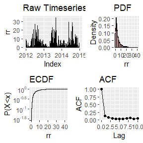

```r
file_path_nc <- system.file("extdata", "rr_ens_mean_0.25deg_reg_2011-2022_v27.0e.nc", package = "anyFit")

coords = data.frame(x = 14.375,y = 62.625)

point_xts = nc2xts_nn(filename = file_path_nc, varname = "rr", coords = coords)

bstats <- basic_stats(point_xts, pstart = '2012',pend = '2014', show_table = FALSE,
                      show_label = FALSE, ignore_zeros = TRUE)
bstats$plot
```

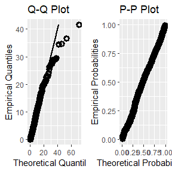

```r
params = fitlm_burr(point_xts, ignore_zeros = TRUE)
fit_check <- fit_diagnostics(point_xts, dist = 'burr',
                             params = params$Param, ignore_zeros = TRUE)

fit_check$Diagnostic_Plots
```

Instead just extracting the timeseries for a given location, we can investigate the timeseries over a region. anyFit provides the option of masking the raw dataset according to a country, continent or an arbitrary shapefile. Note that for the masking to work, both the raw data and the mask have to be in the same coordinate system.

Once the data are loaded we can aggregate them into different scales, for example annual and plot them.

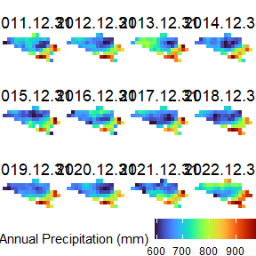

```r
data = nc2xts(filename = file_path_nc, varname = "rr", country = "Belgium")
data_raster = data$raster

annual_data = period_apply_nc(data_raster, period = "years", FUN = "sum")

annual_plot = nc_ggplot(annual_data,title = TRUE,viridis.option = "turbo",
                        legend.title = "Annual Precipitation (mm)", common.legend = TRUE, legend = "bottom")

annual_plot
```

```r
stats = basic_stats_nc(annual_data, ignore_zeros = TRUE)

stats_plot = nc_ggplot(stats[[4:15]])

fits_all = fitlm_nc(data_raster, ignore_zeros = TRUE, candidates = "gamma")

params_plot = nc_ggplot(fits_all$raster_params, viridis.option = "turbo")

Lmom_plot = nc_ggplot(fits_all$raster_TheorLMom, viridis.option = "inferno")
```

Furthermore, we can provide statistics of the annual precipitation of Belgium, for example the mean, variance and the 95th quantile:

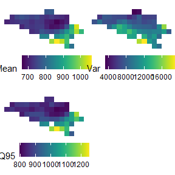

```r
stats = basic_stats_nc(annual_data, ignore_zeros = TRUE)

plot_stats = nc_ggplot(stats[[c("Mean","Var","Q95")]])

plot_stats
```

After we have interogated our data we can fit a distribution:

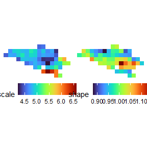

```r
fits_all = fitlm_nc(data_raster, ignore_zeros = TRUE, candidates = "gamma")

params_plot = nc_ggplot(fits_all$raster_params, viridis.option = "turbo")

params_plot
```

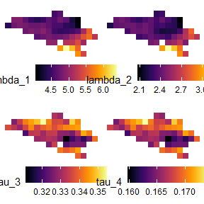

```r
Lmom_plot = nc_ggplot(fits_all$raster_TheorLMom, viridis.option = "inferno")

Lmom_plot
```